# Parte Individual Trabajo Data Science

#### Relación entre horas actividad física y horas de estudio junto con sesiones de tutoría

Para analizar cómo se distribuye la actividad física en relación con las horas de estudio y las sesiones de tutoría, utilizaremos un **diagrama de densidad 2D (Contour Plot)**, el cual permite visualizar las áreas de mayor concentración de datos.

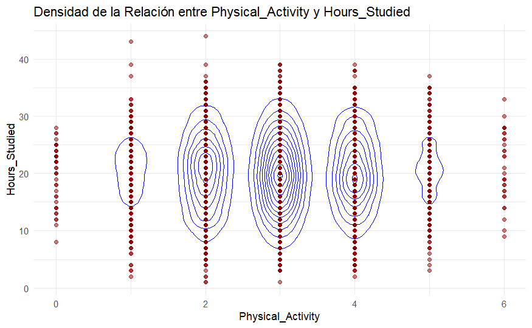

```r
create_density_plot <- function(data, x, y) {
  ggplot(data, aes(x = .data[[x]], y = .data[[y]])) +
    geom_density2d(color = "blue") +
    geom_point(alpha = 0.5, color = "darkred") +
    labs(title = paste("Densidad de la Relación entre", x, "y", y),
         x = x,
         y = y) +
    theme_minimal()
}

create_density_plot(data, "Physical_Activity", "Hours_Studied")
```

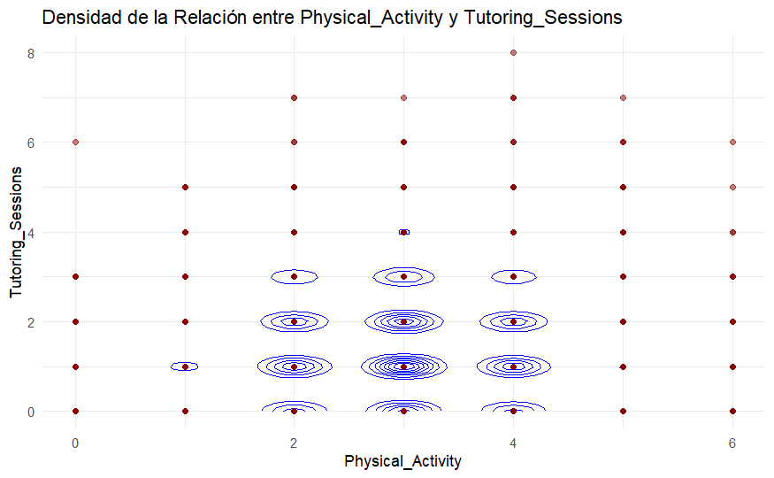

```r
create_density_plot(data, "Physical_Activity", "Tutoring_Sessions")
```

### Preprocesamiento de los datos

**Filtrar las columnas relevantes**

Lo primero que debemos hacer es que como en el proceso de buscar de asociaciones nos centraremos unicamente en las variables académicas y las horas de actividad física, debemos eliminar todas aquellas columnas irrelevantes para este análisis.

Esto nos permitirá concentrarnos únicamente en las variables relacionadas con los **aspectos académicos y la actividad física**. En este caso, seleccionaremos las variables relacionadas con el rendimiento académico: `Previous_Scores`, `Exam_Score`, `Attendance`, `Tutoring_Sessions` y `Hours_Studied` ya que como observamos en la matriz de correlación del trabajo grupal son las que se encuentran directamente relacionadas con el rendimiento académico del estudiante.

```r
df_association_data <- data[, c(academic_vars, "Physical_Activity")]

head(df_association_data)
```

|  | Previous_Scores | Exam_Score | Attendance | Hours_Studied | Tutoring_Sessions | Physical_Activity |
| --- | --- | --- | --- | --- | --- | --- |
| 1 | 73 | 67 | 84 | 23 | 0 | 3 |
| 2 | 59 | 61 | 64 | 19 | 2 | 4 |
| 3 | 91 | 74 | 98 | 24 | 2 | 4 |
| 4 | 98 | 71 | 89 | 29 | 1 | 4 |
| 5 | 65 | 70 | 92 | 19 | 3 | 4 |
| 6 | 89 | 71 | 88 | 19 | 3 | 3 |

**Codificación de variables**

Para ver la distribución de la actividad física de los estudiantes vamos a agrupar las horas de actividad física en los en **rangos de horas**. De esta manera, podemos observar cómo se distribuyen los estudiantes, desde aquellos que no realizan actividad física durante la semana hasta aquellos que practican más horas.

```r
df_association_data <- df_association_data %>%
  mutate(
    Physical_Activity = case_when(
      Physical_Activity == 0 ~ "0 Horas",
      Physical_Activity == 1 ~ "1 Hora",
      Physical_Activity == 2 ~ "2 Horas",
      Physical_Activity == 3 ~ "3 Horas",
      Physical_Activity == 4 ~ "4 Horas",
      Physical_Activity == 5 ~ "5 Horas",
      Physical_Activity > 5 ~ "6 Horas",
      TRUE ~ "Fuera de Rango"
    ),
    # Convertir la columna 'Physical_Activity' a factor
    Physical_Activity = factor(Physical_Activity,
                                levels = c("0 Horas", "1 Hora", "2 Horas", "3 Horas", "4 Horas", "5 Horas", "6 Horas", "Fuera de Rango"))
  )



head(df_association_data)
```

|  | Previous_Scores | Exam_Score | Attendance | Hours_Studied | Tutoring_Sessions | Physical_Activity |
| --- | --- | --- | --- | --- | --- | --- |
| 1 | 73 | 67 | 84 | 23 | 0 | 3 Horas |
| 2 | 59 | 61 | 64 | 19 | 2 | 4 Horas |
| 3 | 91 | 74 | 98 | 24 | 2 | 4 Horas |
| 4 | 98 | 71 | 89 | 29 | 1 | 4 Horas |
| 5 | 65 | 70 | 92 | 19 | 3 | 4 Horas |
| 6 | 89 | 71 | 88 | 19 | 3 | 3 Horas |

A la hora de realizar las reglas de asociación, todas las variables filtradas anteriormente deben ser categóricas. Esto incluye tanto las calificaciones (`Exam_Score` y `Previous_Score`) como otras variables relevantes como la asistencia (`Attendance`), las horas de estudio (`Hours_Studied`), y las sesiones de tutoría (`Tutoring_Sessions`). De este modo, las asociaciones y patrones que encontremos posteriormente mediante reglas de asociación serán más claros y fáciles de interpretar a la hora de extraer conclusiones.

Por tanto, vamos a seguir estos pasos para categorizar las variables académicas y prepararlas para el análisis:

1. **Categorizar las calificaciones** en rangos de puntuación (**“Aprobado”,“Bien”,“Notable”,“Sobresaliente”**).
2. **Categorizar la asistencia** en diferentes grupos, por ejemplo, “**Baja”, “Media” y “Alta”**.
3. **Categorizar las horas de estudio** en cinco rangos: **“Pocas horas”** (0-5), **“Horas moderadas”** (6-15), **“Horas razonables”** (16-30), **“Horas intensivas”** (31-40), **“Excesivas”** (+40).
4. **Categorizar las sesiones de tutoría** en grupos como **“Sin sesiones”, “Pocas sesiones” y “Muchas sesiones”**.

```r
df_association_data <- df_association_data %>%
  mutate(
    # Categorizar el puntaje del examen directamente en la columna 'Exam_Score'
    Exam_Score = case_when(
      Exam_Score >= 50 & Exam_Score <= 69 ~ "Aprobado",
      Exam_Score >= 70 & Exam_Score <= 79 ~ "Bien",
      Exam_Score >= 80 & Exam_Score <= 89 ~ "Notable",
      Exam_Score >= 90 ~ "Sobresaliente",
      TRUE ~ "Fuera de Rango"  # En caso de valores fuera del rango
    ),

    # Categorizar las calificaciones anteriores ('Previous_Scores')
    Previous_Scores = case_when(
      Previous_Scores >= 50 & Previous_Scores <= 69 ~ "Aprobado",
      Previous_Scores >= 70 & Previous_Scores <= 79 ~ "Bien",
      Previous_Scores >= 80 & Previous_Scores <= 89 ~ "Notable",
      Previous_Scores >= 90 ~ "Sobresaliente",
      TRUE ~ "Fuera de Rango"
    ),

    # Categorizar la asistencia ('Attendance')
    Attendance = case_when(
      Attendance < 60 ~ "Baja",  # Ajustado a un límite más realista
      Attendance >= 60 & Attendance < 75 ~ "Media",
      Attendance >= 75 ~ "Alta",
      TRUE ~ "Fuera de Rango"
    ),

    # Categorizar las horas de estudio ('Hours_Studied') en los rangos especificados
    Hours_Studied = case_when(
      Hours_Studied >= 0 & Hours_Studied <= 5 ~ "Pocas horas",
      Hours_Studied >= 6 & Hours_Studied <= 15 ~ "Horas moderadas",
      Hours_Studied >= 16 & Hours_Studied <= 30 ~ "Horas razonables",
      Hours_Studied >= 31 & Hours_Studied <= 40 ~ "Horas intensivas",
      Hours_Studied > 40 ~ "Excesivas",
      TRUE ~ "Fuera de Rango"
    ),

    # Categorizar las sesiones de tutoría ('Tutoring_Sessions')
    Tutoring_Sessions = case_when(
      Tutoring_Sessions == 0 ~ "Sin tutoría",
      Tutoring_Sessions >= 1 & Tutoring_Sessions <= 3 ~ "Pocas sesiones",
      Tutoring_Sessions > 3 ~ "Muchas sesiones",
      TRUE ~ "Fuera de Rango"
    )
  ) %>%
  mutate(
    # Convertir las columnas categóricas a factores
    Exam_Score = factor(Exam_Score, levels = c("Aprobado", "Bien", "Notable", "Sobresaliente", "Fuera de Rango")),
    Previous_Scores = factor(Previous_Scores, levels = c("Aprobado", "Bien", "Notable", "Sobresaliente", "Fuera de Rango")),
    Attendance = factor(Attendance, levels = c("Baja", "Media", "Alta", "Fuera de Rango")),
    Hours_Studied = factor(Hours_Studied, levels = c("Pocas horas", "Horas moderadas", "Horas razonables", "Horas intensivas", "Excesivas", "Fuera de Rango")),
    Tutoring_Sessions = factor(Tutoring_Sessions, levels = c("Sin tutoría", "Pocas sesiones", "Muchas sesiones", "Fuera de Rango"))
  )


head(df_association_data)
```

|  | Previous_Scores | Exam_Score | Attendance | Hours_Studied | Tutoring_Sessions | Physical_Activity |
| --- | --- | --- | --- | --- | --- | --- |
| 1 | Bien | Aprobado | Alta | Horas razonables | Sin tutoría | 3 Horas |
| 2 | Aprobado | Aprobado | Media | Horas razonables | Pocas sesiones | 4 Horas |
| 3 | Sobresaliente | Bien | Alta | Horas razonables | Pocas sesiones | 4 Horas |
| 4 | Sobresaliente | Bien | Alta | Horas razonables | Pocas sesiones | 4 Horas |
| 5 | Aprobado | Bien | Alta | Horas razonables | Pocas sesiones | 4 Horas |
| 6 | Notable | Bien | Alta | Horas razonables | Pocas sesiones | 3 Horas |

```r
str(df_association_data)
```

```
'data.frame':   6378 obs. of  6 variables:
 $ Previous_Scores  : Factor w/ 5 levels "Aprobado","Bien",..: 2 1 4 4 1 3 1 1 3 2 ...
 $ Exam_Score       : Factor w/ 5 levels "Aprobado","Bien",..: 1 1 2 2 2 2 1 1 1 2 ...
 $ Attendance       : Factor w/ 4 levels "Baja","Media",..: 3 2 3 3 3 3 3 3 3 3 ...
 $ Hours_Studied    : Factor w/ 6 levels "Pocas horas",..: 3 3 3 3 3 3 3 3 3 3 ...
 $ Tutoring_Sessions: Factor w/ 4 levels "Sin tutoría",..: 1 2 2 2 2 2 2 2 1 1 ...
 $ Physical_Activity: Factor w/ 8 levels "0 Horas","1 Hora",..: 4 5 5 5 5 4 3 3 2 6 ...
```

## Modelado predictivo

En el análisis exploratorio previo, al examinar las relaciones entre diversas variables, no se observó una influencia clara de algunas características, como las actividades extraescolares, el género y la distancia entre la escuela y hogar, en la actividad física de los estudiantes. Además, se encontró que la distribución de horas de ejercicio físico en relación con las calificaciones previas no presentaba una variación significativa entre las diferentes categorías de notas. Esto sugiere que, en este caso, las variables consideradas no ofrecen una explicación contundente sobre las horas de ejercicio realizadas por los estudiantes.

Dado que no se han encontrado relaciones directas claras en estos análisis iniciales, vamos a profundizar en el estudio de estas relaciones utilizando **reglas de asociación**.

Las **reglas de asociación**, nos van a permitir *identificar numerosas asociaciones frecuentes entre diferentes factores dentro de los datos*, lo que puede ayudarnos a descubrir relaciones ocultas que no se habían evidenciado en el análisis exploratorio inicial.

#### Reglas de asociación

Como se ha destacado anteriormente, las reglas de asociación son una técnica utilizada para identificar patrones y relaciones interesantes entre variables dentro de los conjuntos de datos. En este caso, nos centraremos en identificar asociaciones entre las variables académicas y la actividad física de los estudiantes. De este modo, podremos observar si en verdad la actividad académica del estudiante influye en el tiempo que desempeña en realizar actividad física.

Para realizar este análisis, utilizaremos el **algoritmo Apriori**, que permite descubrir qué combinaciones de variables ocurren frecuentemente juntas dentro de nuestro dataset.

Para ello lo primero que tenemos que hacer en convertir el dataframe a un **formato de transacciones** donde cada fila del dataset se considera como una **transacción**, y cada columna representa un **ítem**. Este formato es el requerido por el algoritmo Apriori.

```r
df_association_data
```

[output not shown]

[output cut: 990 more lines]

```r
df_transactions <- df_association_data %>%
  select(Exam_Score, Previous_Scores, Attendance, Hours_Studied, Tutoring_Sessions, Physical_Activity) %>%
  as("transactions")
```

A continuación, obtenemos las reglas mediante la aplicación de algoritmo donde establecemos los umbrales mínimos de soporte (0.01) y confianza de las reglas (0.5). Esto quiere decir que estamos buscando reglas que ocurran al menos en el 1% de las transacciones y que tengan al menos un 50% de confianza, es decir, significa que si el antecedente de la regla ocurre, al menos el 50% de las veces el consecuente también ocurrirá.

```r
rules <- apriori(df_transactions,
                 parameter = list(support = 0.01, confidence = 0.5, minlen = 2, target = "rules"))
```

```
Apriori

Parameter specification:
```

|  | confidence | minval | smax | arem | aval | originalSupport | maxtime | support | minlen | maxlen | target | ext |
| --- | --- | --- | --- | --- | --- | --- | --- | --- | --- | --- | --- | --- |
|  | 0.5 | 0.1 | 1 | none | FALSE | TRUE | 5 | 0.01 | 2 | 10 | rules | TRUE |

```
Algorithmic control:
```

|  | filter | tree | heap | memopt | load | sort | verbose |
| --- | --- | --- | --- | --- | --- | --- | --- |
|  | 0.1 | TRUE | TRUE | FALSE | TRUE | 2 | TRUE |

```
Absolute minimum support count: 63

set item appearances ...[0 item(s)] done [0.00s].
set transactions ...[25 item(s), 6378 transaction(s)] done [0.00s].
sorting and recoding items ... [19 item(s)] done [0.00s].
creating transaction tree ... done [0.00s].
checking subsets of size 1 2 3 4 5 6 done [0.00s].
writing ... [1574 rule(s)] done [0.00s].
creating S4 object  ... done [0.00s].
```

```r
summary(rules)
```

```
set of 1574 rules

rule length distribution (lhs + rhs):sizes
  2   3   4   5   6
 66 348 647 450  63

   Min. 1st Qu.  Median    Mean 3rd Qu.    Max.
  2.000   3.000   4.000   4.061   5.000   6.000

summary of quality measures:
    support          confidence        coverage            lift            count
 Min.   :0.01003   Min.   :0.5000   Min.   :0.01003   Min.   :0.6648   Min.   :  64.0
 1st Qu.:0.01584   1st Qu.:0.6601   1st Qu.:0.02179   1st Qu.:0.9586   1st Qu.: 101.0
 Median :0.02744   Median :0.7129   Median :0.03841   Median :1.0051   Median : 175.0
 Mean   :0.05002   Mean   :0.7360   Mean   :0.07033   Mean   :1.0682   Mean   : 319.1
 3rd Qu.:0.05358   3rd Qu.:0.7824   3rd Qu.:0.07432   3rd Qu.:1.1054   3rd Qu.: 341.8
 Max.   :0.52603   Max.   :1.0000   Max.   :0.75212   Max.   :3.8138   Max.   :3355.0

mining info:
```

|  | data | ntransactions | support | confidence | call |
| --- | --- | --- | --- | --- | --- |
|  | df_transactions | 6378 | 0.01 | 0.5 | apriori(data = df_transactions, parameter = list(support = 0.01, confidence = 0.5, minlen = 2, target = "rules")) |

```r
inspect(head(rules, 100))
```

```
      lhs                                    rhs                                   support confidence   coverage      lift count
[1]   {Hours_Studied=Horas intensivas}    => {Exam_Score=Bien}                  0.02461587  0.6487603 0.03794293 2.6991477   157
[2]   {Hours_Studied=Horas intensivas}    => {Attendance=Alta}                  0.02351834  0.6198347 0.03794293 0.9694227   150
[3]   {Hours_Studied=Horas intensivas}    => {Tutoring_Sessions=Pocas sesiones} 0.02728128  0.7190083 0.03794293 1.0197542   174
[4]   {Physical_Activity=5 Horas}         => {Attendance=Alta}                  0.03355284  0.6184971 0.05424898 0.9673307   214
[5]   {Physical_Activity=5 Horas}         => {Tutoring_Sessions=Pocas sesiones} 0.03606146  0.6647399 0.05424898 0.9427865   230
[6]   {Physical_Activity=5 Horas}         => {Hours_Studied=Horas razonables}   0.03825651  0.7052023 0.05424898 0.9604485   244
[7]   {Physical_Activity=5 Horas}         => {Exam_Score=Aprobado}              0.03904045  0.7196532 0.05424898 0.9568372   249
[8]   {Physical_Activity=1 Hora}          => {Attendance=Alta}                  0.04029476  0.6425000 0.06271558 1.0048713   257
[9]   {Physical_Activity=1 Hora}          => {Tutoring_Sessions=Pocas sesiones} 0.04515522  0.7200000 0.06271558 1.0211608   288
[10]  {Physical_Activity=1 Hora}          => {Hours_Studied=Horas razonables}   0.04782063  0.7625000 0.06271558 1.0384849   305
[11]  {Physical_Activity=1 Hora}          => {Exam_Score=Aprobado}              0.04703669  0.7500000 0.06271558 0.9971857   300
[12]  {Tutoring_Sessions=Muchas sesiones} => {Attendance=Alta}                  0.04201944  0.6335697 0.06632173 0.9909043   268
[13]  {Tutoring_Sessions=Muchas sesiones} => {Hours_Studied=Horas razonables}   0.04938852  0.7446809 0.06632173 1.0142162   315
[14]  {Tutoring_Sessions=Muchas sesiones} => {Exam_Score=Aprobado}              0.04107871  0.6193853 0.06632173 0.8235230   262
```

[output cut: 120 more lines]

Hemos obtenido un total de **1574 Reglas**. Sin embargo, dado que estamos interesados en las asociaciones que involucren las horas de actividad física (`Physical_Activity`), vamos a filtrar las reglas generadas para mostrar solo aquellas que estén directamente relacionadas con esta variable.

```r
# Filtrar las reglas cuyo consecuente contiene cualquier valor de 'Physical_Activity'
physical_activity_rules <- apriori(df_transactions,
                 parameter = list(support = 0.01, confidence = 0.5, minlen = 2),
                 appearance = list(rhs = c("Physical_Activity=0 Horas", "Physical_Activity=1 Hora", "Physical_Activity=2 Horas",
                                           "Physical_Activity=3 Horas", "Physical_Activity=4 Horas", "Physical_Activity=5 Horas",
                                           "Physical_Activity=6 Horas", "Physical_Activity=Fuera de Rango"),
                                   default = "lhs"))
```

```
Apriori

Parameter specification:
```

|  | confidence | minval | smax | arem | aval | originalSupport | maxtime | support | minlen | maxlen | target | ext |
| --- | --- | --- | --- | --- | --- | --- | --- | --- | --- | --- | --- | --- |
|  | 0.5 | 0.1 | 1 | none | FALSE | TRUE | 5 | 0.01 | 2 | 10 | rules | TRUE |

```
Algorithmic control:
```

|  | filter | tree | heap | memopt | load | sort | verbose |
| --- | --- | --- | --- | --- | --- | --- | --- |
|  | 0.1 | TRUE | TRUE | FALSE | TRUE | 2 | TRUE |

```
Absolute minimum support count: 63

set item appearances ...[8 item(s)] done [0.00s].
set transactions ...[26 item(s), 6378 transaction(s)] done [0.00s].
sorting and recoding items ... [19 item(s)] done [0.00s].
creating transaction tree ... done [0.00s].
checking subsets of size 1 2 3 4 5 6 done [0.00s].
writing ... [0 rule(s)] done [0.00s].
creating S4 object  ... done [0.00s].
```

```r
summary(physical_activity_rules)
```

```
set of 0 rules
```

```r
inspect(head(physical_activity_rules,10))
```

Observamos que no se encontraron reglas en las que `Physical_Activity` aparezca en el consecuente. Por ello, será necesario **reducir el valor de confianza de 0.5 a un umbral más bajo**, permitiendo la generación de reglas menos restrictivas. Esto aumentará la cantidad de asociaciones detectadas y podría revelar patrones que antes no eran visibles. Sin embargo, a su vez esto va a reducir las restricciones, es decir, se relaja la exigencia de cuanto de fuerte debe ser la relación entre el antecedente y el consecuente para ser considerada una regla interesante.

Por tanto, ahora vamos a probar con un **confidence = 0.3**.

**Reglas de asociación con confidence = 0.3**

```r
# Filtrar las reglas con confidence 0.3
physical_activity_rules_03 <- apriori(df_transactions,
                 parameter = list(support = 0.01, confidence = 0.3, minlen = 2),
                 appearance = list(rhs = c("Physical_Activity=0 Horas", "Physical_Activity=1 Hora", "Physical_Activity=2 Horas",
                                           "Physical_Activity=3 Horas", "Physical_Activity=4 Horas", "Physical_Activity=5 Horas",
                                           "Physical_Activity=6 Horas", "Physical_Activity=Fuera de Rango"),
                                   default = "lhs"))
```

```
Apriori

Parameter specification:
```

|  | confidence | minval | smax | arem | aval | originalSupport | maxtime | support | minlen | maxlen | target | ext |
| --- | --- | --- | --- | --- | --- | --- | --- | --- | --- | --- | --- | --- |
|  | 0.3 | 0.1 | 1 | none | FALSE | TRUE | 5 | 0.01 | 2 | 10 | rules | TRUE |

```
Algorithmic control:
```

|  | filter | tree | heap | memopt | load | sort | verbose |
| --- | --- | --- | --- | --- | --- | --- | --- |
|  | 0.1 | TRUE | TRUE | FALSE | TRUE | 2 | TRUE |

```
Absolute minimum support count: 63

set item appearances ...[8 item(s)] done [0.00s].
set transactions ...[26 item(s), 6378 transaction(s)] done [0.00s].
sorting and recoding items ... [19 item(s)] done [0.00s].
creating transaction tree ... done [0.00s].
checking subsets of size 1 2 3 4 5 6 done [0.00s].
writing ... [250 rule(s)] done [0.00s].
creating S4 object  ... done [0.00s].
```

```r
summary(physical_activity_rules_03)
```

```
set of 250 rules

rule length distribution (lhs + rhs):sizes
  2   3   4   5   6
 14  59 100  64  13

   Min. 1st Qu.  Median    Mean 3rd Qu.    Max.
  2.000   3.000   4.000   4.012   5.000   6.000

summary of quality measures:
    support          confidence        coverage            lift            count
 Min.   :0.01003   Min.   :0.3037   Min.   :0.02446   Min.   :0.8429   Min.   :  64.0
 1st Qu.:0.01619   1st Qu.:0.3710   1st Qu.:0.04159   1st Qu.:0.9623   1st Qu.: 103.2
 Median :0.02407   Median :0.3857   Median :0.06585   Median :1.0010   Median : 153.5
 Mean   :0.04349   Mean   :0.3864   Mean   :0.11266   Mean   :1.0075   Mean   : 277.4
 3rd Qu.:0.05272   3rd Qu.:0.4038   3rd Qu.:0.13923   3rd Qu.:1.0492   3rd Qu.: 336.2
 Max.   :0.29304   Max.   :0.4667   Max.   :0.75212   Max.   :1.2997   Max.   :1869.0

mining info:
```

|  | data | ntransactions | support | confidence | call |
| --- | --- | --- | --- | --- | --- |
|  | df_transactions | 6378 | 0.01 | 0.3 | apriori(data = df_transactions, parameter = list(support = 0.01, confidence = 0.3, minlen = 2), appearance = list(rhs = c("Physical_Activity=0 Horas", "Physical_Activity=1 Hora", "Physical_Activity=2 … |

```r
inspect(head(physical_activity_rules_03,10))
```

|  | lhs |  | rhs | support | confidence | coverage | lift | count |
| --- | --- | --- | --- | --- | --- | --- | --- | --- |
| [1] | {Hours_Studied=Horas intensivas} | => | {Physical_Activity=3 Horas} | 0.01458137 | 0.3842975 | 0.03794293 | 0.9963616 | 93 |
| [2] | {Tutoring_Sessions=Muchas sesiones} | => | {Physical_Activity=3 Horas} | 0.02508623 | 0.3782506 | 0.06632173 | 0.9806838 | 160 |
| [3] | {Previous_Scores=Bien} | => | {Physical_Activity=3 Horas} | 0.07353402 | 0.3684211 | 0.19959235 | 0.9551990 | 469 |
| [4] | {Previous_Scores=Notable} | => | {Physical_Activity=3 Horas} | 0.08011916 | 0.3973561 | 0.20163061 | 1.0302185 | 511 |
| [5] | {Previous_Scores=Sobresaliente} | => | {Physical_Activity=3 Horas} | 0.08435246 | 0.4017924 | 0.20994042 | 1.0417202 | 538 |
| [6] | {Hours_Studied=Horas moderadas} | => | {Physical_Activity=3 Horas} | 0.08795861 | 0.4021505 | 0.21872060 | 1.0426488 | 561 |
| [7] | {Tutoring_Sessions=Sin tutoría} | => | {Physical_Activity=3 Horas} | 0.08544998 | 0.3737997 | 0.22859831 | 0.9691442 | 545 |
| [8] | {Exam_Score=Bien} | => | {Physical_Activity=3 Horas} | 0.09031044 | 0.3757339 | 0.24035748 | 0.9741588 | 576 |
| [9] | {Attendance=Media} | => | {Physical_Activity=3 Horas} | 0.13907181 | 0.3856522 | 0.36061461 | 0.9998738 | 887 |
| [10] | {Previous_Scores=Aprobado} | => | {Physical_Activity=3 Horas} | 0.14769520 | 0.3798387 | 0.38883663 | 0.9848013 | 942 |

Después de reducir el umbral de confianza, se han identificado un total de **250 reglas** con `Physical_Activity` como consecuente.

A continuación, se genera un gráfico de dispersión para visualizar el equilibrio entre soporte y confianza, resaltando el valor de lift para identificar asociaciones más significativas.

```
To reduce overplotting, jitter is added! Use jitter = 0 to prevent jitter.
```

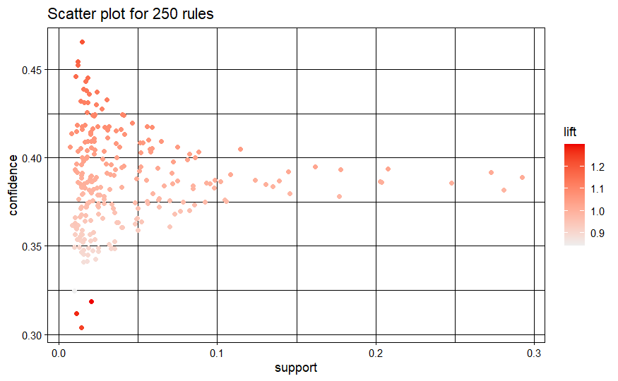

```r
plot(physical_activity_rules_03, method = "scatterplot", measure = c("support", "confidence"), shading = "lift")
```

Observamos que las asociaciones más significativas en términos de lift tienden a formarse alrededor del umbral de confianza establecido (0.3). Esto sugiere que, si bien estas reglas no tienen una confianza extremadamente alta, su capacidad para mejorar la predicción de `Physical_Activity` en comparación con el azar sigue siendo notable.

Para profundizar en estas asociaciones, vamos a analizar las **10 reglas con mayor lift**, ya que estas representan las combinaciones de variables más relevantes para predecir `Physical_Activity`.

```r
high_lift_rules_03 <- head(sort(physical_activity_rules_03, by = "lift"), 10)
inspect(high_lift_rules_03)
```

```
     lhs                                   rhs                            support confidence   coverage     lift count
[1]  {Exam_Score=Aprobado,
      Previous_Scores=Bien,
      Attendance=Alta,
      Hours_Studied=Horas razonables}   => {Physical_Activity=2 Horas} 0.01771715  0.3183099 0.05566008 1.299731   113
[2]  {Exam_Score=Aprobado,
      Previous_Scores=Bien,
      Attendance=Alta,
      Hours_Studied=Horas razonables,
      Tutoring_Sessions=Pocas sesiones} => {Physical_Activity=2 Horas} 0.01222954  0.3120000 0.03919724 1.273967    78
[3]  {Exam_Score=Aprobado,
      Previous_Scores=Sobresaliente,
      Attendance=Alta,
      Tutoring_Sessions=Pocas sesiones} => {Physical_Activity=2 Horas} 0.01285669  0.3037037 0.04233302 1.240091    82
[4]  {Previous_Scores=Sobresaliente,
      Attendance=Alta,
      Hours_Studied=Horas moderadas}    => {Physical_Activity=3 Horas} 0.01317027  0.4666667 0.02822201 1.209919    84
[5]  {Exam_Score=Aprobado,
      Previous_Scores=Sobresaliente,
      Attendance=Alta,
      Hours_Studied=Horas moderadas}    => {Physical_Activity=3 Horas} 0.01113202  0.4551282 0.02445908 1.180003    71
[6]  {Exam_Score=Aprobado,
      Previous_Scores=Sobresaliente,
      Hours_Studied=Horas moderadas,
      Tutoring_Sessions=Pocas sesiones} => {Physical_Activity=3 Horas} 0.01222954  0.4508671 0.02712449 1.168955    78
[7]  {Previous_Scores=Sobresaliente,
      Hours_Studied=Horas moderadas,
      Tutoring_Sessions=Pocas sesiones} => {Physical_Activity=3 Horas} 0.01332706  0.4473684 0.02978990 1.159884    85
[8]  {Exam_Score=Bien,
      Previous_Scores=Notable,
      Tutoring_Sessions=Pocas sesiones} => {Physical_Activity=3 Horas} 0.01834431  0.4448669 0.04123550 1.153399   117
[9]  {Exam_Score=Bien,
      Previous_Scores=Notable,
      Hours_Studied=Horas razonables,
      Tutoring_Sessions=Pocas sesiones} => {Physical_Activity=3 Horas} 0.01536532  0.4414414 0.03480715 1.144518    98
[10] {Exam_Score=Bien,
      Previous_Scores=Notable,
      Attendance=Alta,
      Tutoring_Sessions=Pocas sesiones} => {Physical_Activity=3 Horas} 0.01709000  0.4377510 0.03904045 1.134950   109
```

Dentro de las 10 reglas con mayor Lift, encontramos que únicamente los valores **Physical_Activity=2 Horas** y **Physical_Activity=3 Horas** aparecen como consecuentes. Es decir, las reglas más significativas desde el punto de vista de la relación entre el antecedente y el consecuente (según la métrica del Lift) son aquellas que predicen que un estudiante realiza 2 o 3 horas de actividad física.

Sin embargo, no encontramos reglas donde los consecuentes sean **0 horas, 1 hora, o, por otro lado, más de 4 horas de actividad física**. Este patrón puede deberse a varias razones, y una explicación relevante es la que surgió durante el análisis exploratorio: **la mayoría de los estudiantes tienden a concentrarse en torno a 2 o 3 horas de actividad física**.

Por último, vamos a visualizar las reglas con mayor lift mediante un gráfico de red para explorar las relaciones entre los antecedentes y **Physical_Activity**, para así poder analizar dichas asociaciones y establecer conclusiones al estudio.

```r
# Visualización de las reglas encontradas
plot(high_lift_rules_03, method = "graph", engine = "htmlwidget")
```

[interactive chart not shown]

**Análisis de las reglas**

Se observa que los estudiantes con calificaciones **aprobadas**, **alta asistencia** y **horas razonables de estudio** tienen una mayor probabilidad de realizar **2 horas de actividad física**. Además destacar que esto se refuerza cuando se incluyen características como **pocas sesiones de tutoría** y **calificaciones sobresalientes** en los exámenes previos, aunque la fuerza de la asociación disminuye ligeramente al incluir estos factores adicionales.

Por otro lado, también se identifican asociaciones significativas para aquellos estudiantes con calificaciones sobresalientes o notables, que muestran una probabilidad elevada de realizar **3 horas de actividad física**, especialmente cuando se combinan con asistencia alta y horas de estudio moderadas. La explicación es que puede que a medida de que los estudiantes tengan una mayor calificación y una asistencia y horarios estudio más constante, es más probable que sus horas empleadas a la actividad física aumenten.

El valor de lift en estas reglas, que varía entre 1.13 y 1.30, sugiere que las asociaciones encontradas tienen una relación moderadamente significativa con las horas de actividad física, siendo ligeramente más fuertes que el azar.

**Reglas de asociación con confidence= 0.2**

En el análisis previo, al utilizar un valor de confianza de 0.3, observamos que solo se generaron reglas cuyo consecuente era de 2 y 3 horas de actividad física. Sin embargo, al no encontrar reglas con otros valores, como menos de 2 horas o más de 4 horas, se va a probar con un umbral de confianza más bajo, **0.2**. Esto permitirá la inclusión de reglas que, aunque no sean tan fuertes como las anteriores, podrían ser relevantes para el estudio.

De este modo, se va a permitir la detección de reglas menos frecuentes, es decir, aquellas en las que el antecedente y el consecuente no se presentan con tanta regularidad. Esto facilita la identificación de asociaciones que de otro modo habrían sido descartadas debido a su baja frecuencia. Sin embargo, **estas asociaciones serán menos confiables en comparación con las reglas generadas con un umbral de confianza más alto**.

Además, en esta ocasión decidimos excluir las reglas previamente obtenidas que tenían como consecuente 2 y 3 horas, ya que estas ya se habían identificado en el análisis anterior.

```r
# Filtrar las reglas con confidence 0.2
physical_activity_rules_02 <- apriori(df_transactions,
                 parameter = list(support = 0.01, confidence = 0.2, minlen = 2),
                 appearance = list(rhs = c("Physical_Activity=0 Horas", "Physical_Activity=1 Hora", "Physical_Activity=4 Horas", "Physical_Activity=5 Horas",
                                           "Physical_Activity=6 Horas", "Physical_Activity=Fuera de Rango"),
                                   default = "lhs"))
```

```
Apriori

Parameter specification:
```

|  | confidence | minval | smax | arem | aval | originalSupport | maxtime | support | minlen | maxlen | target | ext |
| --- | --- | --- | --- | --- | --- | --- | --- | --- | --- | --- | --- | --- |
|  | 0.2 | 0.1 | 1 | none | FALSE | TRUE | 5 | 0.01 | 2 | 10 | rules | TRUE |

```
Algorithmic control:
```

|  | filter | tree | heap | memopt | load | sort | verbose |
| --- | --- | --- | --- | --- | --- | --- | --- |
|  | 0.1 | TRUE | TRUE | FALSE | TRUE | 2 | TRUE |

```
Absolute minimum support count: 63

set item appearances ...[6 item(s)] done [0.00s].
set transactions ...[26 item(s), 6378 transaction(s)] done [0.00s].
sorting and recoding items ... [19 item(s)] done [0.00s].
creating transaction tree ... done [0.00s].
checking subsets of size 1 2 3 4 5 6 done [0.00s].
writing ... [181 rule(s)] done [0.00s].
creating S4 object  ... done [0.00s].
```

```r
summary(physical_activity_rules_02)
```

```
set of 181 rules

rule length distribution (lhs + rhs):sizes
 2  3  4  5  6
13 55 71 39  3

   Min. 1st Qu.  Median    Mean 3rd Qu.    Max.
  2.000   3.000   4.000   3.801   4.000   6.000

summary of quality measures:
    support          confidence        coverage            lift            count
 Min.   :0.01003   Min.   :0.2081   Min.   :0.04014   Min.   :0.8645   Min.   :  64.0
 1st Qu.:0.01364   1st Qu.:0.2276   1st Qu.:0.05848   1st Qu.:0.9455   1st Qu.:  87.0
 Median :0.02148   Median :0.2391   Median :0.09360   Median :0.9936   Median : 137.0
 Mean   :0.03432   Mean   :0.2420   Mean   :0.14208   Mean   :1.0056   Mean   : 218.9
 3rd Qu.:0.04280   3rd Qu.:0.2544   3rd Qu.:0.17341   3rd Qu.:1.0572   3rd Qu.: 273.0
 Max.   :0.18140   Max.   :0.2970   Max.   :0.75212   Max.   :1.2341   Max.   :1157.0

mining info:
```

|  | data | ntransactions | support | confidence | call |
| --- | --- | --- | --- | --- | --- |
|  | df_transactions | 6378 | 0.01 | 0.2 | apriori(data = df_transactions, parameter = list(support = 0.01, confidence = 0.2, minlen = 2), appearance = list(rhs = c("Physical_Activity=0 Horas", "Physical_Activity=1 Hora", "Physical_Activity=4 … |

```r
inspect(head(physical_activity_rules_02,10))
```

|  | lhs |  | rhs | support | confidence | coverage | lift | count |
| --- | --- | --- | --- | --- | --- | --- | --- | --- |
| [1] | {Tutoring_Sessions=Muchas sesiones} | => | {Physical_Activity=4 Horas} | 0.01787394 | 0.2695035 | 0.06632173 | 1.1198004 | 114 |
| [2] | {Previous_Scores=Bien} | => | {Physical_Activity=4 Horas} | 0.04844779 | 0.2427337 | 0.19959235 | 1.0085704 | 309 |
| [3] | {Previous_Scores=Notable} | => | {Physical_Activity=4 Horas} | 0.04640953 | 0.2301711 | 0.20163061 | 0.9563721 | 296 |
| [4] | {Previous_Scores=Sobresaliente} | => | {Physical_Activity=4 Horas} | 0.04938852 | 0.2352502 | 0.20994042 | 0.9774760 | 315 |
| [5] | {Hours_Studied=Horas moderadas} | => | {Physical_Activity=4 Horas} | 0.04844779 | 0.2215054 | 0.21872060 | 0.9203657 | 309 |
| [6] | {Tutoring_Sessions=Sin tutoría} | => | {Physical_Activity=4 Horas} | 0.05456256 | 0.2386831 | 0.22859831 | 0.9917401 | 348 |
| [7] | {Exam_Score=Bien} | => | {Physical_Activity=4 Horas} | 0.06177485 | 0.2570124 | 0.24035748 | 1.0678991 | 394 |
| [8] | {Attendance=Media} | => | {Physical_Activity=4 Horas} | 0.08984008 | 0.2491304 | 0.36061461 | 1.0351491 | 573 |
| [9] | {Previous_Scores=Aprobado} | => | {Physical_Activity=4 Horas} | 0.09642521 | 0.2479839 | 0.38883663 | 1.0303851 | 615 |
| [10] | {Attendance=Alta} | => | {Physical_Activity=4 Horas} | 0.15083098 | 0.2359000 | 0.63938539 | 0.9801758 | 962 |

Después de reducir el umbral de confianza, se han identificado un total de **181 reglas** con `Physical_Activity` como consecuente.

A continuación, se genera un gráfico de dispersión para visualizar el equilibrio entre soporte y confianza, resaltando el valor de lift para identificar asociaciones más significativas.

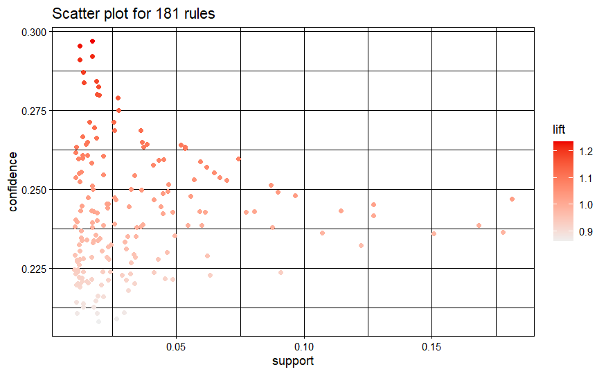

```r
plot(physical_activity_rules_02, method = "scatterplot", measure = c("support", "confidence"), shading = "lift")
```

Al igual que en el anterior scatter plot vemos que las reglas con mayor lift se encuentran cercanas al 0.3 de confidence. Esto puede significar que dichas reglas son más interesantes en términos relativos (alto lift) aunque no ocurren con mucha frecuencia (confidence baja).

```r
high_lift_rules_02 <- head(sort(physical_activity_rules_02, by = "lift"), 10)
inspect(high_lift_rules_02)
```

```
     lhs                                   rhs                            support confidence   coverage     lift count
[1]  {Exam_Score=Bien,
      Previous_Scores=Aprobado,
      Attendance=Alta,
      Hours_Studied=Horas razonables}   => {Physical_Activity=4 Horas} 0.01709000  0.2970027 0.05754155 1.234061   109
[2]  {Exam_Score=Bien,
      Previous_Scores=Aprobado,
      Attendance=Alta,
      Hours_Studied=Horas razonables,
      Tutoring_Sessions=Pocas sesiones} => {Physical_Activity=4 Horas} 0.01222954  0.2954545 0.04139229 1.227628    78
[3]  {Exam_Score=Bien,
      Previous_Scores=Aprobado,
      Hours_Studied=Horas razonables}   => {Physical_Activity=4 Horas} 0.01709000  0.2922252 0.05848228 1.214210   109
[4]  {Exam_Score=Bien,
      Previous_Scores=Aprobado,
      Hours_Studied=Horas razonables,
      Tutoring_Sessions=Pocas sesiones} => {Physical_Activity=4 Horas} 0.01222954  0.2910448 0.04201944 1.209305    78
[5]  {Exam_Score=Bien,
      Previous_Scores=Aprobado,
      Attendance=Alta,
      Tutoring_Sessions=Pocas sesiones} => {Physical_Activity=4 Horas} 0.01364064  0.2871287 0.04750706 1.193034    87
[6]  {Exam_Score=Bien,
      Previous_Scores=Aprobado,
      Attendance=Alta}                  => {Physical_Activity=4 Horas} 0.01881468  0.2843602 0.06616494 1.181530   120
[7]  {Exam_Score=Bien,
      Previous_Scores=Aprobado,
      Tutoring_Sessions=Pocas sesiones} => {Physical_Activity=4 Horas} 0.01379743  0.2838710 0.04860458 1.179498    88
[8]  {Exam_Score=Aprobado,
      Previous_Scores=Aprobado,
      Attendance=Media,
      Hours_Studied=Horas razonables,
      Tutoring_Sessions=Pocas sesiones} => {Physical_Activity=4 Horas} 0.01944183  0.2824601 0.06883035 1.173636   124
[9]  {Exam_Score=Bien,
      Previous_Scores=Aprobado}         => {Physical_Activity=4 Horas} 0.01897146  0.2800926 0.06773283 1.163798   121
[10] {Previous_Scores=Aprobado,
      Attendance=Media,
      Hours_Studied=Horas razonables,
      Tutoring_Sessions=Pocas sesiones} => {Physical_Activity=4 Horas} 0.01975541  0.2800000 0.07055503 1.163414   126
```

Entre las reglas generadas, observamos que únicamente hay asociaciones en las que el consecuente es **Physical_Activity=4 Horas**, lo que indica que las reglas tienden a relacionarse con estudiantes que realizan cuatro horas de actividad física. Este patrón se repite en la mayoría de las reglas, independientemente de las características del antecedente, como la puntuación en los exámenes, el número de sesiones de tutoría o la asistencia.

Vamos a examinar más a fondo las reglas observando el gráfico de red generado.

```r
plot(high_lift_rules_02, method = "graph", engine = "htmlwidget")
```

[interactive chart not shown]

**Análisis de reglas**

El **impacto de las tutorías es más limitado, pero aún presente**, ya que las reglas que incluyen la variable de pocas sesiones de tutoría tienden a mostrar una leve disminución en la probabilidad de realizar 4 horas de actividad física en comparación con aquellas sin tutorías. Además, se observa que la asistencia media en combinación con horas razonables de estudio y pocas sesiones de tutoría también está asociada con una probabilidad de realizar 4 horas de actividad física.

### EXTRA: Exploración de Reglas de Asociación con el Conjunto Completo de Datos

En esta sección adicional, se ampliará el análisis de reglas de asociación para incluir todas las variables del conjunto de datos, con el objetivo de explorar posibles patrones más complejos y relaciones entre las variables académicas y la actividad física de los estudiantes.

A diferencia del análisis previo, que se centró únicamente en las variables académicas relacionadas directamente con la actividad física, en este apartado se buscarán asociaciones más amplias que puedan ofrecer una visión más completa sobre los factores que influyen en el tiempo que los estudiantes dedican al ejercicio físico. Este enfoque permitirá identificar patrones y comprender cómo diversas características del desempeño académico, la asistencia, las calificaciones previas y otras variables podrían estar vinculadas con las horas de actividad física realizadas.

```r
df_all_vars <- data

df_all_vars <- df_all_vars %>%
  select(-School_Type_Public, -Gender_Female, -Previous_Scores_Category)

head(df_all_vars)
```

|  | Previous_Scores | Hours_Studied | Attendance | Parental_Involvement | Access_to_Resources | Extracurricular_Activities | Sleep_Hours | Motivation_Level | Internet_Access | Tutoring_Sessions | Family_Income | Teacher_Quality | Peer_Influence | Physical_Activity | Learning_Disabilities | Parental_Education_Level | Distance_from_Home | Exam_Score | School_Type_Private | Gender_Male |
| --- | --- | --- | --- | --- | --- | --- | --- | --- | --- | --- | --- | --- | --- | --- | --- | --- | --- | --- | --- | --- |
| 1 | 73 | 23 | 84 | 1 | 3 | 0 | 7 | 1 | 1 | 0 | 1 | 2 | 3 | 3 | 0 | 1 | 1 | 67 | 0 | 1 |
| 2 | 59 | 19 | 64 | 1 | 2 | 0 | 8 | 1 | 1 | 2 | 2 | 2 | 1 | 4 | 0 | 2 | 2 | 61 | 0 | 0 |
| 3 | 91 | 24 | 98 | 2 | 2 | 1 | 7 | 2 | 1 | 2 | 2 | 2 | 2 | 4 | 0 | 3 | 1 | 74 | 0 | 1 |
| 4 | 98 | 29 | 89 | 1 | 2 | 1 | 8 | 2 | 1 | 1 | 2 | 2 | 1 | 4 | 0 | 1 | 2 | 71 | 0 | 1 |
| 5 | 65 | 19 | 92 | 2 | 2 | 1 | 6 | 2 | 1 | 3 | 2 | 3 | 2 | 4 | 0 | 2 | 1 | 70 | 0 | 0 |
| 6 | 89 | 19 | 88 | 2 | 2 | 1 | 8 | 2 | 1 | 3 | 2 | 2 | 3 | 3 | 0 | 3 | 1 | 71 | 0 | 1 |

```r
str(df_all_vars)
```

```
'data.frame':   6378 obs. of  20 variables:
 $ Previous_Scores           : int  73 59 91 98 65 89 68 50 80 71 ...
 $ Hours_Studied             : int  23 19 24 29 19 19 29 25 17 23 ...
 $ Attendance                : int  84 64 98 89 92 88 84 78 94 98 ...
 $ Parental_Involvement      : int  1 1 2 1 2 2 2 1 2 2 ...
 $ Access_to_Resources       : int  3 2 2 2 2 2 1 3 3 2 ...
 $ Extracurricular_Activities: int  0 0 1 1 1 1 1 1 0 1 ...
 $ Sleep_Hours               : int  7 8 7 8 6 8 7 6 6 8 ...
 $ Motivation_Level          : int  1 1 2 2 2 2 1 2 3 2 ...
 $ Internet_Access           : int  1 1 1 1 1 1 1 1 1 1 ...
 $ Tutoring_Sessions         : int  0 2 2 1 3 3 1 1 0 0 ...
 $ Family_Income             : int  1 2 2 2 2 2 1 3 2 3 ...
 $ Teacher_Quality           : int  2 2 2 2 3 2 2 3 1 3 ...
 $ Peer_Influence            : int  3 1 2 1 2 3 2 1 2 3 ...
 $ Physical_Activity         : int  3 4 4 4 4 3 2 2 1 5 ...
 $ Learning_Disabilities     : int  0 0 0 0 0 0 0 0 0 0 ...
 $ Parental_Education_Level  : int  1 2 3 1 2 3 1 1 2 1 ...
 $ Distance_from_Home        : int  1 2 1 2 1 1 2 3 1 2 ...
 $ Exam_Score                : int  67 61 74 71 70 71 67 66 69 72 ...
 $ School_Type_Private       : int  0 0 0 0 0 0 1 0 1 0 ...
 $ Gender_Male               : int  1 0 1 1 0 1 1 1 1 1 ...
```

A continuación, debemos recategorizar todas las variables que habian sido pasadas a numérico en el preprocesamiento de `global.Rmd`.

```r
df_all_vars <- recategorize_variable(df_all_vars, "Parental_Involvement", c("Low", "Medium", "High"))
df_all_vars <- recategorize_variable(df_all_vars, "Access_to_Resources", c("Low", "Medium", "High"))
df_all_vars <- recategorize_variable(df_all_vars, "Motivation_Level", c("Low", "Medium", "High"))
df_all_vars <- recategorize_variable(df_all_vars, "Parental_Education_Level", c("High School", "College", "Postgraduate"))
df_all_vars <- recategorize_variable(df_all_vars, "Family_Income", c("Low", "Medium", "High"))
df_all_vars <- recategorize_variable(df_all_vars, "Teacher_Quality", c("Low", "Medium", "High"))
df_all_vars <- recategorize_variable(df_all_vars, "Distance_from_Home", c("Near", "Moderate", "Far"))
df_all_vars <- recategorize_variable(df_all_vars, "Peer_Influence", c("Negative", "Neutral", "Positive"))

df_all_vars$Extracurricular_Activities <- factor(df_all_vars$Extracurricular_Activities, levels = c(0, 1), labels = c("No", "Yes"))
df_all_vars$Internet_Access <- factor(df_all_vars$Internet_Access, levels = c(0, 1), labels = c("No", "Yes"))
df_all_vars$Learning_Disabilities <- factor(df_all_vars$Learning_Disabilities, levels = c(0, 1), labels = c("No", "Yes"))
df_all_vars$School_Type_Private <- factor(df_all_vars$School_Type_Private, levels = c(0, 1), labels = c("No", "Yes"))
df_all_vars$Gender_Male <- factor(df_all_vars$Gender_Male, levels = c(0, 1), labels = c("No", "Yes"))

head(df_all_vars)
```

|  | Previous_Scores | Hours_Studied | Attendance | Parental_Involvement | Access_to_Resources | Extracurricular_Activities | Sleep_Hours | Motivation_Level | Internet_Access | Tutoring_Sessions | Family_Income | Teacher_Quality | Peer_Influence | Physical_Activity | Learning_Disabilities | Parental_Education_Level | Distance_from_Home | Exam_Score | School_Type_Private | Gender_Male |
| --- | --- | --- | --- | --- | --- | --- | --- | --- | --- | --- | --- | --- | --- | --- | --- | --- | --- | --- | --- | --- |
| 1 | 73 | 23 | 84 | Low | High | No | 7 | Low | Yes | 0 | Low | Medium | Positive | 3 | No | High School | Near | 67 | No | Yes |
| 2 | 59 | 19 | 64 | Low | Medium | No | 8 | Low | Yes | 2 | Medium | Medium | Negative | 4 | No | College | Moderate | 61 | No | No |
| 3 | 91 | 24 | 98 | Medium | Medium | Yes | 7 | Medium | Yes | 2 | Medium | Medium | Neutral | 4 | No | Postgraduate | Near | 74 | No | Yes |
| 4 | 98 | 29 | 89 | Low | Medium | Yes | 8 | Medium | Yes | 1 | Medium | Medium | Negative | 4 | No | High School | Moderate | 71 | No | Yes |
| 5 | 65 | 19 | 92 | Medium | Medium | Yes | 6 | Medium | Yes | 3 | Medium | High | Neutral | 4 | No | College | Near | 70 | No | No |
| 6 | 89 | 19 | 88 | Medium | Medium | Yes | 8 | Medium | Yes | 3 | Medium | Medium | Positive | 3 | No | Postgraduate | Near | 71 | No | Yes |

```r
str(df_all_vars)
```

```
'data.frame':   6378 obs. of  20 variables:
 $ Previous_Scores           : int  73 59 91 98 65 89 68 50 80 71 ...
 $ Hours_Studied             : int  23 19 24 29 19 19 29 25 17 23 ...
 $ Attendance                : int  84 64 98 89 92 88 84 78 94 98 ...
 $ Parental_Involvement      : Factor w/ 3 levels "Low","Medium",..: 1 1 2 1 2 2 2 1 2 2 ...
 $ Access_to_Resources       : Factor w/ 3 levels "Low","Medium",..: 3 2 2 2 2 2 1 3 3 2 ...
 $ Extracurricular_Activities: Factor w/ 2 levels "No","Yes": 1 1 2 2 2 2 2 2 1 2 ...
 $ Sleep_Hours               : int  7 8 7 8 6 8 7 6 6 8 ...
 $ Motivation_Level          : Factor w/ 3 levels "Low","Medium",..: 1 1 2 2 2 2 1 2 3 2 ...
 $ Internet_Access           : Factor w/ 2 levels "No","Yes": 2 2 2 2 2 2 2 2 2 2 ...
 $ Tutoring_Sessions         : int  0 2 2 1 3 3 1 1 0 0 ...
 $ Family_Income             : Factor w/ 3 levels "Low","Medium",..: 1 2 2 2 2 2 1 3 2 3 ...
 $ Teacher_Quality           : Factor w/ 3 levels "Low","Medium",..: 2 2 2 2 3 2 2 3 1 3 ...
 $ Peer_Influence            : Factor w/ 3 levels "Negative","Neutral",..: 3 1 2 1 2 3 2 1 2 3 ...
 $ Physical_Activity         : int  3 4 4 4 4 3 2 2 1 5 ...
 $ Learning_Disabilities     : Factor w/ 2 levels "No","Yes": 1 1 1 1 1 1 1 1 1 1 ...
 $ Parental_Education_Level  : Factor w/ 3 levels "High School",..: 1 2 3 1 2 3 1 1 2 1 ...
 $ Distance_from_Home        : Factor w/ 3 levels "Near","Moderate",..: 1 2 1 2 1 1 2 3 1 2 ...
 $ Exam_Score                : int  67 61 74 71 70 71 67 66 69 72 ...
 $ School_Type_Private       : Factor w/ 2 levels "No","Yes": 1 1 1 1 1 1 2 1 2 1 ...
 $ Gender_Male               : Factor w/ 2 levels "No","Yes": 2 1 2 2 1 2 2 2 2 2 ...
```

```r
df_all_vars <- df_all_vars %>%
  mutate(
    # Categorizar el puntaje del examen directamente en la columna 'Exam_Score'
    Exam_Score = case_when(
      Exam_Score >= 50 & Exam_Score <= 69 ~ "Aprobado",
      Exam_Score >= 70 & Exam_Score <= 79 ~ "Bien",
      Exam_Score >= 80 & Exam_Score <= 89 ~ "Notable",
      Exam_Score >= 90 ~ "Sobresaliente",
      TRUE ~ "Fuera de Rango"  # En caso de valores fuera del rango
    ),

    # Categorizar las calificaciones anteriores ('Previous_Scores')
    Previous_Scores = case_when(
      Previous_Scores >= 50 & Previous_Scores <= 69 ~ "Aprobado",
      Previous_Scores >= 70 & Previous_Scores <= 79 ~ "Bien",
      Previous_Scores >= 80 & Previous_Scores <= 89 ~ "Notable",
      Previous_Scores >= 90 ~ "Sobresaliente",
      TRUE ~ "Fuera de Rango"
    ),

    # Categorizar la asistencia ('Attendance')
    Attendance = case_when(
      Attendance < 60 ~ "Baja",  # Ajustado a un límite más realista
      Attendance >= 60 & Attendance < 75 ~ "Media",
      Attendance >= 75 ~ "Alta",
      TRUE ~ "Fuera de Rango"
    ),

    # Categorizar las horas de estudio ('Hours_Studied') en los rangos especificados
    Hours_Studied = case_when(
      Hours_Studied >= 0 & Hours_Studied <= 5 ~ "Pocas horas",
      Hours_Studied >= 6 & Hours_Studied <= 15 ~ "Horas moderadas",
      Hours_Studied >= 16 & Hours_Studied <= 30 ~ "Horas razonables",
      Hours_Studied >= 31 & Hours_Studied <= 40 ~ "Horas intensivas",
      Hours_Studied > 40 ~ "Excesivas",
      TRUE ~ "Fuera de Rango"
    ),

    # Categorizar las sesiones de tutoría ('Tutoring_Sessions')
    Tutoring_Sessions = case_when(
      Tutoring_Sessions == 0 ~ "Sin tutoría",
      Tutoring_Sessions >= 1 & Tutoring_Sessions <= 3 ~ "Pocas sesiones",
      Tutoring_Sessions > 3 ~ "Muchas sesiones",
      TRUE ~ "Fuera de Rango"
    ),

    # Categorizar las horas de estudio ('Hours_Studied') en los rangos especificados
    Sleep_Hours = case_when(
      Sleep_Hours >= 0 & Sleep_Hours <= 6 ~ "Poco sueño",
      Sleep_Hours >= 7 & Sleep_Hours <= 9 ~ "Sueño moderado",
      Sleep_Hours >= 10 ~ "Mucho sueño",
      TRUE ~ "Datos inválidos"
    )

  ) %>%
  mutate(
    # Convertir las columnas categóricas a factores
    Exam_Score = factor(Exam_Score, levels = c("Aprobado", "Bien", "Notable", "Sobresaliente", "Fuera de Rango")),
    Sleep_Hours = factor(Sleep_Hours, levels = c("Poco sueño", "Sueño moderado", "Mucho sueño", "Fuera de Rango")),
    Previous_Scores = factor(Previous_Scores, levels = c("Aprobado", "Bien", "Notable", "Sobresaliente", "Fuera de Rango")),
    Attendance = factor(Attendance, levels = c("Baja", "Media", "Alta", "Fuera de Rango")),
    Hours_Studied = factor(Hours_Studied, levels = c("Pocas horas", "Horas moderadas", "Horas razonables", "Horas intensivas", "Excesivas", "Fuera de Rango")),
    Tutoring_Sessions = factor(Tutoring_Sessions, levels = c("Sin tutoría", "Pocas sesiones", "Muchas sesiones", "Fuera de Rango"))
  )
```

En este caso, categorizamos la variable `Physical_Activity` en 3 grupos:

```r
df_all_vars <- df_all_vars %>%
  mutate(
    Physical_Activity = case_when(
      Physical_Activity >= 0 & Physical_Activity <= 1  ~ "Poca actividad",
      Physical_Activity >= 2 & Physical_Activity <= 4 ~ "Media actividad",
      Physical_Activity >= 5 ~ "Mucha actividad",
      TRUE ~ "Fuera de Rango"
    ),

    Physical_Activity = factor(Physical_Activity,
                                levels = c("Poca actividad", "Media actividad", "Mucha actividad", "Fuera de Rango"))
  )

head(df_all_vars)
```

|  | Previous_Scores | Hours_Studied | Attendance | Parental_Involvement | Access_to_Resources | Extracurricular_Activities | Sleep_Hours | Motivation_Level | Internet_Access | Tutoring_Sessions | Family_Income | Teacher_Quality | Peer_Influence | Physical_Activity | Learning_Disabilities | Parental_Education_Level | Distance_from_Home | Exam_Score | School_Type_Private | Gender_Male |
| --- | --- | --- | --- | --- | --- | --- | --- | --- | --- | --- | --- | --- | --- | --- | --- | --- | --- | --- | --- | --- |
| 1 | Bien | Horas razonables | Alta | Low | High | No | Sueño moderado | Low | Yes | Sin tutoría | Low | Medium | Positive | Media actividad | No | High School | Near | Aprobado | No | Yes |
| 2 | Aprobado | Horas razonables | Media | Low | Medium | No | Sueño moderado | Low | Yes | Pocas sesiones | Medium | Medium | Negative | Media actividad | No | College | Moderate | Aprobado | No | No |
| 3 | Sobresaliente | Horas razonables | Alta | Medium | Medium | Yes | Sueño moderado | Medium | Yes | Pocas sesiones | Medium | Medium | Neutral | Media actividad | No | Postgraduate | Near | Bien | No | Yes |
| 4 | Sobresaliente | Horas razonables | Alta | Low | Medium | Yes | Sueño moderado | Medium | Yes | Pocas sesiones | Medium | Medium | Negative | Media actividad | No | High School | Moderate | Bien | No | Yes |
| 5 | Aprobado | Horas razonables | Alta | Medium | Medium | Yes | Poco sueño | Medium | Yes | Pocas sesiones | Medium | High | Neutral | Media actividad | No | College | Near | Bien | No | No |
| 6 | Notable | Horas razonables | Alta | Medium | Medium | Yes | Sueño moderado | Medium | Yes | Pocas sesiones | Medium | Medium | Positive | Media actividad | No | Postgraduate | Near | Bien | No | Yes |

```r
str(df_all_vars)
```

```
'data.frame':   6378 obs. of  20 variables:
 $ Previous_Scores           : Factor w/ 5 levels "Aprobado","Bien",..: 2 1 4 4 1 3 1 1 3 2 ...
 $ Hours_Studied             : Factor w/ 6 levels "Pocas horas",..: 3 3 3 3 3 3 3 3 3 3 ...
 $ Attendance                : Factor w/ 4 levels "Baja","Media",..: 3 2 3 3 3 3 3 3 3 3 ...
 $ Parental_Involvement      : Factor w/ 3 levels "Low","Medium",..: 1 1 2 1 2 2 2 1 2 2 ...
 $ Access_to_Resources       : Factor w/ 3 levels "Low","Medium",..: 3 2 2 2 2 2 1 3 3 2 ...
 $ Extracurricular_Activities: Factor w/ 2 levels "No","Yes": 1 1 2 2 2 2 2 2 1 2 ...
 $ Sleep_Hours               : Factor w/ 4 levels "Poco sueño","Sueño moderado",..: 2 2 2 2 1 2 2 1 1 2 ...
 $ Motivation_Level          : Factor w/ 3 levels "Low","Medium",..: 1 1 2 2 2 2 1 2 3 2 ...
 $ Internet_Access           : Factor w/ 2 levels "No","Yes": 2 2 2 2 2 2 2 2 2 2 ...
 $ Tutoring_Sessions         : Factor w/ 4 levels "Sin tutoría",..: 1 2 2 2 2 2 2 2 1 1 ...
 $ Family_Income             : Factor w/ 3 levels "Low","Medium",..: 1 2 2 2 2 2 1 3 2 3 ...
 $ Teacher_Quality           : Factor w/ 3 levels "Low","Medium",..: 2 2 2 2 3 2 2 3 1 3 ...
 $ Peer_Influence            : Factor w/ 3 levels "Negative","Neutral",..: 3 1 2 1 2 3 2 1 2 3 ...
 $ Physical_Activity         : Factor w/ 4 levels "Poca actividad",..: 2 2 2 2 2 2 2 2 1 3 ...
 $ Learning_Disabilities     : Factor w/ 2 levels "No","Yes": 1 1 1 1 1 1 1 1 1 1 ...
 $ Parental_Education_Level  : Factor w/ 3 levels "High School",..: 1 2 3 1 2 3 1 1 2 1 ...
 $ Distance_from_Home        : Factor w/ 3 levels "Near","Moderate",..: 1 2 1 2 1 1 2 3 1 2 ...
 $ Exam_Score                : Factor w/ 5 levels "Aprobado","Bien",..: 1 1 2 2 2 2 1 1 1 2 ...
 $ School_Type_Private       : Factor w/ 2 levels "No","Yes": 1 1 1 1 1 1 2 1 2 1 ...
 $ Gender_Male               : Factor w/ 2 levels "No","Yes": 2 1 2 2 1 2 2 2 2 2 ...
```

Hemos categorizado todas las variables necesarias por lo que el siguiente paso es realizar el análisis de reglas de asociación.

Antes que nada, vamos a asegurarnos de que los datos estén en un formato adecuado para el algoritmo Apriori. Esto implica convertir las variables categóricas a un formato de transacción, que es el que acepta dicho algoritmo.

```r
df_all_vars_factor <- df_all_vars %>%
  select_if(is.factor)

transacciones <- as(df_all_vars_factor, "transactions")
summary(transacciones)
```

```
transactions as itemMatrix in sparse format with
 6378 rows (elements/itemsets/transactions) and
 66 columns (items) and a density of 0.3030303

most frequent items:
              Internet_Access=Yes          Learning_Disabilities=No
                             5893                              5710
Physical_Activity=Media actividad               Exam_Score=Aprobado
                             5557                              4797
   Hours_Studied=Horas razonables                           (Other)
                             4683                            100920

element (itemset/transaction) length distribution:
sizes
  20
6378

   Min. 1st Qu.  Median    Mean 3rd Qu.    Max.
     20      20      20      20      20      20

includes extended item information - examples:
```

|  | labels | variables | levels |
| --- | --- | --- | --- |
| 1 | Previous_Scores=Aprobado | Previous_Scores | Aprobado |
| 2 | Previous_Scores=Bien | Previous_Scores | Bien |
| 3 | Previous_Scores=Notable | Previous_Scores | Notable |

```
includes extended transaction information - examples:
```

|  | transactionID |
| --- | --- |
| 1 | 1 |
| 2 | 2 |
| 3 | 3 |

En este caso, como tenemos muchas más variables que en el estudio anterior vamos a aumentar los umbrales mínimos de soporte y confianza.

- Umbral de soporte: **0.1**
- Confianza: **0.8**

Esto quiere decir que estamos buscando reglas que ocurran al menos en el 10% de las transacciones y que tengan al menos un 80% de confianza, es decir, significa que si el antecedente de la regla ocurre, al menos el 80% de las veces el consecuente también ocurrirá.

```r
reglas <- apriori(transacciones,
                  parameter = list(supp = 0.1, conf = 0.8, target = "rules"))
```

```
Apriori

Parameter specification:
```

|  | confidence | minval | smax | arem | aval | originalSupport | maxtime | support | minlen | maxlen | target | ext |
| --- | --- | --- | --- | --- | --- | --- | --- | --- | --- | --- | --- | --- |
|  | 0.8 | 0.1 | 1 | none | FALSE | TRUE | 5 | 0.1 | 1 | 10 | rules | TRUE |

```
Algorithmic control:
```

|  | filter | tree | heap | memopt | load | sort | verbose |
| --- | --- | --- | --- | --- | --- | --- | --- |
|  | 0.1 | TRUE | TRUE | FALSE | TRUE | 2 | TRUE |

```
Absolute minimum support count: 637

set item appearances ...[0 item(s)] done [0.00s].
set transactions ...[58 item(s), 6378 transaction(s)] done [0.01s].
sorting and recoding items ... [47 item(s)] done [0.00s].
creating transaction tree ... done [0.00s].
checking subsets of size 1 2 3 4 5 6 7 8 done [0.23s].
writing ... [30489 rule(s)] done [0.02s].
creating S4 object  ... done [0.01s].
```

```r
summary(reglas)
```

```
set of 30489 rules

rule length distribution (lhs + rhs):sizes
    1     2     3     4     5     6     7     8
    3   141  1914  7267 11731  7802  1613    18

   Min. 1st Qu.  Median    Mean 3rd Qu.    Max.
  1.000   4.000   5.000   4.985   6.000   8.000

summary of quality measures:
    support         confidence        coverage           lift            count
 Min.   :0.1000   Min.   :0.8000   Min.   :0.1027   Min.   :0.9578   Min.   : 638.0
 1st Qu.:0.1101   1st Qu.:0.8802   1st Qu.:0.1226   1st Qu.:0.9947   1st Qu.: 702.0
 Median :0.1259   Median :0.8987   Median :0.1403   Median :1.0018   Median : 803.0
 Mean   :0.1445   Mean   :0.8990   Mean   :0.1609   Mean   :1.0106   Mean   : 921.6
 3rd Qu.:0.1569   3rd Qu.:0.9197   3rd Qu.:0.1754   3rd Qu.:1.0098   3rd Qu.:1001.0
 Max.   :0.9240   Max.   :0.9845   Max.   :1.0000   Max.   :1.5212   Max.   :5893.0

mining info:
```

|  | data | ntransactions | support | confidence | call |
| --- | --- | --- | --- | --- | --- |
|  | transacciones | 6378 | 0.1 | 0.8 | apriori(data = transacciones, parameter = list(supp = 0.1, conf = 0.8, target = "rules")) |

En este caso, el algoritmo ha generado **30,489 reglas**. El soporte mínimo es 0.1 y el promedio es 0.1445, indicando que las reglas ocurren en al menos el 10% de las transacciones. La confianza mínima tiene un promedio de 0.899, lo que significa que las reglas son bastante confiables. Respecto al Lift, el promedio es 1.0106, mostrando una relación positiva entre los elementos de las reglas.

La longitud de las reglas varía entre 1 y 8 elementos, siendo las más comunes las de 4 a 6 elementos.

Mostramos las 10 primeras reglas generadas:

```r
# Ver las primeras 10 reglas
inspect(head(reglas, 10))
```

|  | lhs |  | rhs | support | confidence | coverage | lift | count |
| --- | --- | --- | --- | --- | --- | --- | --- | --- |
| [1] | {} | => | {Physical_Activity=Media actividad} | 0.8712763 | 0.8712763 | 1.0000000 | 1.0000000 | 5557 |
| [2] | {} | => | {Learning_Disabilities=No} | 0.8952650 | 0.8952650 | 1.0000000 | 1.0000000 | 5710 |
| [3] | {} | => | {Internet_Access=Yes} | 0.9239574 | 0.9239574 | 1.0000000 | 1.0000000 | 5893 |
| [4] | {Family_Income=High} | => | {Physical_Activity=Media actividad} | 0.1661963 | 0.8617886 | 0.1928504 | 0.9891106 | 1060 |
| [5] | {Family_Income=High} | => | {Learning_Disabilities=No} | 0.1712135 | 0.8878049 | 0.1928504 | 0.9916672 | 1092 |
| [6] | {Family_Income=High} | => | {Internet_Access=Yes} | 0.1770147 | 0.9178862 | 0.1928504 | 0.9934292 | 1129 |
| [7] | {Previous_Scores=Bien} | => | {Physical_Activity=Media actividad} | 0.1756036 | 0.8798115 | 0.1995923 | 1.0097962 | 1120 |
| [8] | {Previous_Scores=Bien} | => | {Learning_Disabilities=No} | 0.1795234 | 0.8994501 | 0.1995923 | 1.0046748 | 1145 |
| [9] | {Previous_Scores=Bien} | => | {Internet_Access=Yes} | 0.1845406 | 0.9245876 | 0.1995923 | 1.0006821 | 1177 |
| [10] | {Access_to_Resources=Low} | => | {Exam_Score=Aprobado} | 0.1687049 | 0.8445840 | 0.1997491 | 1.1229428 | 1076 |

```r
# Ordenar las reglas por confianza
reglas_ordenadas <- sort(reglas, by = "confidence", decreasing = TRUE)
inspect(head(reglas_ordenadas, 10))
```

```
     lhs                                       rhs                     support confidence  coverage     lift count
[1]  {Hours_Studied=Horas razonables,
      Attendance=Media,
      Internet_Access=Yes,
      Learning_Disabilities=No,
      Parental_Education_Level=High School} => {Exam_Score=Aprobado} 0.1092819  0.9844633 0.1110066 1.308924   697
[2]  {Hours_Studied=Horas razonables,
      Attendance=Media,
      Learning_Disabilities=No,
      Parental_Education_Level=High School} => {Exam_Score=Aprobado} 0.1175917  0.9842520 0.1194732 1.308643   750
[3]  {Hours_Studied=Horas razonables,
      Attendance=Media,
      Access_to_Resources=Medium,
      Internet_Access=Yes,
      Physical_Activity=Media actividad}    => {Exam_Score=Aprobado} 0.1059893  0.9839884 0.1077140 1.308292   676
[4]  {Hours_Studied=Horas razonables,
      Attendance=Media,
      Physical_Activity=Media actividad,
      Learning_Disabilities=No,
      Parental_Education_Level=High School} => {Exam_Score=Aprobado} 0.1025400  0.9834586 0.1042647 1.307588   654
[5]  {Hours_Studied=Horas razonables,
      Attendance=Media,
      Access_to_Resources=Medium,
      Physical_Activity=Media actividad,
      Learning_Disabilities=No}             => {Exam_Score=Aprobado} 0.1025400  0.9819820 0.1044214 1.305625   654
[6]  {Hours_Studied=Horas razonables,
      Attendance=Media,
      Access_to_Resources=Medium,
      Internet_Access=Yes,
      Learning_Disabilities=No}             => {Exam_Score=Aprobado} 0.1100659  0.9818182 0.1121041 1.305407   702
[7]  {Hours_Studied=Horas razonables,
      Attendance=Media,
      Access_to_Resources=Medium,
      Internet_Access=Yes}                  => {Exam_Score=Aprobado} 0.1227658  0.9812030 0.1251176 1.304589   783
[8]  {Attendance=Media,
      Internet_Access=Yes,
      Tutoring_Sessions=Pocas sesiones,
      Learning_Disabilities=No,
      Parental_Education_Level=High School} => {Exam_Score=Aprobado} 0.1063029  0.9811867 0.1083412 1.304567   678
[9]  {Hours_Studied=Horas razonables,
      Attendance=Media,
      Access_to_Resources=Medium,
      Physical_Activity=Media actividad}    => {Exam_Score=Aprobado} 0.1133584  0.9810041 0.1155535 1.304324   723
[10] {Attendance=Media,
      Internet_Access=Yes,
      Tutoring_Sessions=Pocas sesiones,
      Parental_Education_Level=High School} => {Exam_Score=Aprobado} 0.1186892  0.9805699 0.1210411 1.303747   757
```

```r
# Filtrar las reglas cuyo consecuente contiene 'Poca actividad'
reglas_actividad <- apriori(transacciones,
                 parameter = list(support = 0.1, confidence = 0.8, minlen = 2),
                 appearance = list(rhs = c("Physical_Activity=Poca actividad", "Physical_Activity=Media actividad", "Physical_Activity=Mucha actividad"),
                                   default = "lhs"))
```

```
Apriori

Parameter specification:
```

|  | confidence | minval | smax | arem | aval | originalSupport | maxtime | support | minlen | maxlen | target | ext |
| --- | --- | --- | --- | --- | --- | --- | --- | --- | --- | --- | --- | --- |
|  | 0.8 | 0.1 | 1 | none | FALSE | TRUE | 5 | 0.1 | 2 | 10 | rules | TRUE |

```
Algorithmic control:
```

|  | filter | tree | heap | memopt | load | sort | verbose |
| --- | --- | --- | --- | --- | --- | --- | --- |
|  | 0.1 | TRUE | TRUE | FALSE | TRUE | 2 | TRUE |

```
Absolute minimum support count: 637

set item appearances ...[3 item(s)] done [0.00s].
set transactions ...[58 item(s), 6378 transaction(s)] done [0.01s].
sorting and recoding items ... [47 item(s)] done [0.00s].
creating transaction tree ... done [0.00s].
checking subsets of size 1 2 3 4 5 6 7 8 done [0.25s].
writing ... [9319 rule(s)] done [0.01s].
creating S4 object  ... done [0.01s].
```

```r
summary(reglas_actividad)
```

```
set of 9319 rules

rule length distribution (lhs + rhs):sizes
   2    3    4    5    6    7    8
  44  576 2205 3558 2408  522    6

   Min. 1st Qu.  Median    Mean 3rd Qu.    Max.
  2.000   4.000   5.000   4.998   6.000   8.000

summary of quality measures:
    support         confidence        coverage           lift            count
 Min.   :0.1000   Min.   :0.8390   Min.   :0.1101   Min.   :0.9629   Min.   : 638.0
 1st Qu.:0.1104   1st Qu.:0.8685   1st Qu.:0.1261   1st Qu.:0.9968   1st Qu.: 704.0
 Median :0.1262   Median :0.8753   Median :0.1441   Median :1.0046   Median : 805.0
 Mean   :0.1449   Mean   :0.8754   Mean   :0.1655   Mean   :1.0048   Mean   : 924.1
 3rd Qu.:0.1577   3rd Qu.:0.8819   3rd Qu.:0.1803   3rd Qu.:1.0122   3rd Qu.:1006.0
 Max.   :0.8051   Max.   :0.9144   Max.   :0.9240   Max.   :1.0495   Max.   :5135.0

mining info:
```

|  | data | ntransactions | support | confidence | call |
| --- | --- | --- | --- | --- | --- |
|  | transacciones | 6378 | 0.1 | 0.8 | apriori(data = transacciones, parameter = list(support = 0.1, confidence = 0.8, minlen = 2), appearance = list(rhs = c("Physical_Activity=Poca actividad", "Physical_Activity=Media actividad", "Physica… |

```r
inspect(head(reglas_actividad, 100))
```

```
      lhs                                         rhs                                   support confidence  coverage      lift count
[1]   {Family_Income=High}                     => {Physical_Activity=Media actividad} 0.1661963  0.8617886 0.1928504 0.9891106  1060
[2]   {Previous_Scores=Bien}                   => {Physical_Activity=Media actividad} 0.1756036  0.8798115 0.1995923 1.0097962  1120
[3]   {Access_to_Resources=Low}                => {Physical_Activity=Media actividad} 0.1748197  0.8751962 0.1997491 1.0044991  1115
[4]   {Motivation_Level=High}                  => {Physical_Activity=Media actividad} 0.1745061  0.8715740 0.2002195 1.0003417  1113
[5]   {Parental_Education_Level=Postgraduate}  => {Physical_Activity=Media actividad} 0.1729382  0.8617187 0.2006899 0.9890304  1103
[6]   {Previous_Scores=Notable}                => {Physical_Activity=Media actividad} 0.1754468  0.8701400 0.2016306 0.9986958  1119
[7]   {Parental_Involvement=Low}               => {Physical_Activity=Media actividad} 0.1721543  0.8505035 0.2024146 0.9761582  1098
[8]   {Peer_Influence=Negative}                => {Physical_Activity=Media actividad} 0.1817184  0.8714286 0.2085293 1.0001748  1159
[9]   {Previous_Scores=Sobresaliente}          => {Physical_Activity=Media actividad} 0.1818752  0.8663181 0.2099404 0.9943094  1160
[10]  {Hours_Studied=Horas moderadas}          => {Physical_Activity=Media actividad} 0.1915961  0.8759857 0.2187206 1.0054052  1222
[11]  {Tutoring_Sessions=Sin tutoría}          => {Physical_Activity=Media actividad} 0.1969269  0.8614540 0.2285983 0.9887266  1256
[12]  {Exam_Score=Bien}                        => {Physical_Activity=Media actividad} 0.2063343  0.8584475 0.2403575 0.9852759  1316
[13]  {Parental_Involvement=High}              => {Physical_Activity=Media actividad} 0.2499216  0.8681917 0.2878645 0.9964597  1594
[14]  {Motivation_Level=Low}                   => {Physical_Activity=Media actividad} 0.2579178  0.8825107 0.2922546 1.0128943  1645
[15]  {Access_to_Resources=High}               => {Physical_Activity=Media actividad} 0.2577611  0.8652632 0.2978990 0.9930985  1644
[16]  {Teacher_Quality=High}                   => {Physical_Activity=Media actividad} 0.2641894  0.8845144 0.2986830 1.0151940  1685
[17]  {Parental_Education_Level=College}       => {Physical_Activity=Media actividad} 0.2651301  0.8720990 0.3040138 1.0009443  1691
[18]  {Distance_from_Home=Moderate}            => {Physical_Activity=Media actividad} 0.2649733  0.8706852 0.3043274 0.9993216  1690
[19]  {School_Type_Private=Yes}                => {Physical_Activity=Media actividad} 0.2670116  0.8760288 0.3047977 1.0054547  1703
[20]  {Sleep_Hours=Poco sueño}                 => {Physical_Activity=Media actividad} 0.3113829  0.8687664 0.3584196 0.9971193  1986
[21]  {Attendance=Media}                       => {Physical_Activity=Media actividad} 0.3131076  0.8682609 0.3606146 0.9965391  1997
[22]  {Previous_Scores=Aprobado}               => {Physical_Activity=Media actividad} 0.3383506  0.8701613 0.3888366 0.9987203  2158
[23]  {Peer_Influence=Neutral}                 => {Physical_Activity=Media actividad} 0.3397617  0.8685371 0.3911885 0.9968561  2167
[24]  {Peer_Influence=Positive}                => {Physical_Activity=Media actividad} 0.3497962  0.8738739 0.4002822 1.0029814  2231
[25]  {Family_Income=Medium}                   => {Physical_Activity=Media actividad} 0.3527752  0.8768511 0.4023205 1.0063985  2250
[26]  {Extracurricular_Activities=No}          => {Physical_Activity=Media actividad} 0.3494826  0.8669778 0.4031044 0.9950665  2229
[27]  {Family_Income=Low}                      => {Physical_Activity=Media actividad} 0.3523048  0.8702556 0.4048291 0.9988286  2247
[28]  {Gender_Male=No}                         => {Physical_Activity=Media actividad} 0.3668862  0.8698885 0.4217623 0.9984072  2340
[29]  {Parental_Education_Level=High School}   => {Physical_Activity=Media actividad} 0.4332079  0.8746439 0.4952963 1.0038651  2763
[30]  {Access_to_Resources=Medium}             => {Physical_Activity=Media actividad} 0.4386955  0.8732834 0.5023518 1.0023037  2798
[31]  {Motivation_Level=Medium}                => {Physical_Activity=Media actividad} 0.4388523  0.8646895 0.5075259 0.9924401  2799
[32]  {Parental_Involvement=Medium}            => {Physical_Activity=Media actividad} 0.4492004  0.8812673 0.5097209 1.0114671  2865
[33]  {Gender_Male=Yes}                        => {Physical_Activity=Media actividad} 0.5043901  0.8722885 0.5782377 1.0011618  3217
[34]  {Sleep_Hours=Sueño moderado}             => {Physical_Activity=Media actividad} 0.5186579  0.8730536 0.5940734 1.0020399  3308
[35]  {Distance_from_Home=Near}                => {Physical_Activity=Media actividad} 0.5200690  0.8726651 0.5959548 1.0015940  3317
[36]  {Extracurricular_Activities=Yes}         => {Physical_Activity=Media actividad} 0.5217937  0.8741791 0.5968956 1.0033318  3328
[37]  {Teacher_Quality=Medium}                 => {Physical_Activity=Media actividad} 0.5191283  0.8653947 0.5998746 0.9932494  3311
[38]  {Attendance=Alta}                        => {Physical_Activity=Media actividad} 0.5581687  0.8729769 0.6393854 1.0019519  3560
[39]  {School_Type_Private=No}                 => {Physical_Activity=Media actividad} 0.6042647  0.8691926 0.6952023 0.9976085  3854
```

[output cut: 102 more lines]

```
       School_Type_Private=No}                 => {Physical_Activity=Media actividad} 0.1166510  0.8631090 0.1351521 0.9906261   744
[94]  {Tutoring_Sessions=Pocas sesiones,
       Parental_Education_Level=Postgraduate}  => {Physical_Activity=Media actividad} 0.1233929  0.8582334 0.1437755 0.9850301   787
[95]  {Hours_Studied=Horas razonables,
       Parental_Education_Level=Postgraduate}  => {Physical_Activity=Media actividad} 0.1277830  0.8560924 0.1492631 0.9825729   815
[96]  {Parental_Education_Level=Postgraduate,
       Exam_Score=Aprobado}                    => {Physical_Activity=Media actividad} 0.1185325  0.8571429 0.1382879 0.9837785   756
[97]  {Learning_Disabilities=No,
       Parental_Education_Level=Postgraduate}  => {Physical_Activity=Media actividad} 0.1566322  0.8686957 0.1803073 0.9970381   999
[98]  {Internet_Access=Yes,
       Parental_Education_Level=Postgraduate}  => {Physical_Activity=Media actividad} 0.1610223  0.8630252 0.1865789 0.9905299  1027
[99]  {Previous_Scores=Notable,
       Gender_Male=Yes}                        => {Physical_Activity=Media actividad} 0.1023832  0.8800539 0.1163374 1.0100745   653
[100] {Previous_Scores=Notable,
       Sleep_Hours=Sueño moderado}             => {Physical_Activity=Media actividad} 0.1036375  0.8708827 0.1190028 0.9995483   661
```

```r
summary(reglas_actividad)
```

```
set of 9319 rules

rule length distribution (lhs + rhs):sizes
   2    3    4    5    6    7    8
  44  576 2205 3558 2408  522    6

   Min. 1st Qu.  Median    Mean 3rd Qu.    Max.
  2.000   4.000   5.000   4.998   6.000   8.000

summary of quality measures:
    support         confidence        coverage           lift            count
 Min.   :0.1000   Min.   :0.8390   Min.   :0.1101   Min.   :0.9629   Min.   : 638.0
 1st Qu.:0.1104   1st Qu.:0.8685   1st Qu.:0.1261   1st Qu.:0.9968   1st Qu.: 704.0
 Median :0.1262   Median :0.8753   Median :0.1441   Median :1.0046   Median : 805.0
 Mean   :0.1449   Mean   :0.8754   Mean   :0.1655   Mean   :1.0048   Mean   : 924.1
 3rd Qu.:0.1577   3rd Qu.:0.8819   3rd Qu.:0.1803   3rd Qu.:1.0122   3rd Qu.:1006.0
 Max.   :0.8051   Max.   :0.9144   Max.   :0.9240   Max.   :1.0495   Max.   :5135.0

mining info:
```

|  | data | ntransactions | support | confidence | call |
| --- | --- | --- | --- | --- | --- |
|  | transacciones | 6378 | 0.1 | 0.8 | apriori(data = transacciones, parameter = list(support = 0.1, confidence = 0.8, minlen = 2), appearance = list(rhs = c("Physical_Activity=Poca actividad", "Physical_Activity=Media actividad", "Physica… |

```
To reduce overplotting, jitter is added! Use jitter = 0 to prevent jitter.
```

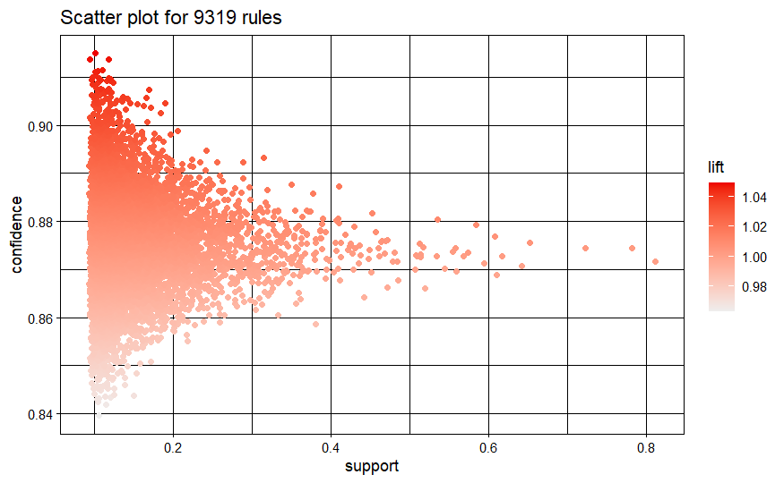

```r
plot(reglas_actividad, method = "scatterplot", measure = c("support", "confidence"), shading = "lift")
```

```r
high_lift_reglas_actividad <- head(sort(reglas_actividad, by = "lift"), 10)
inspect(high_lift_reglas_actividad)
```

```
     lhs                                    rhs                                   support confidence  coverage     lift count
[1]  {Extracurricular_Activities=Yes,
      Tutoring_Sessions=Pocas sesiones,
      Teacher_Quality=High,
      Learning_Disabilities=No}          => {Physical_Activity=Media actividad} 0.1072437  0.9144385 0.1172781 1.049539   684
[2]  {Hours_Studied=Horas razonables,
      Attendance=Alta,
      Parental_Involvement=Medium,
      Internet_Access=Yes,
      Learning_Disabilities=No,
      Exam_Score=Aprobado}               => {Physical_Activity=Media actividad} 0.1009721  0.9134752 0.1105362 1.048433   644
[3]  {Hours_Studied=Horas razonables,
      Attendance=Alta,
      Parental_Involvement=Medium,
      Learning_Disabilities=No,
      Exam_Score=Aprobado}               => {Physical_Activity=Media actividad} 0.1119473  0.9130435 0.1226090 1.047938   714
[4]  {Parental_Involvement=Medium,
      Sleep_Hours=Sueño moderado,
      Teacher_Quality=Medium,
      Learning_Disabilities=No,
      Exam_Score=Aprobado}               => {Physical_Activity=Media actividad} 0.1105362  0.9120310 0.1211979 1.046776   705
[5]  {Attendance=Alta,
      Parental_Involvement=Medium,
      Family_Income=Medium,
      Learning_Disabilities=No}          => {Physical_Activity=Media actividad} 0.1064597  0.9114094 0.1168078 1.046062   679
[6]  {Parental_Involvement=Medium,
      Sleep_Hours=Sueño moderado,
      Internet_Access=Yes,
      Teacher_Quality=Medium,
      Learning_Disabilities=No,
      Exam_Score=Aprobado}               => {Physical_Activity=Media actividad} 0.1031671  0.9113573 0.1132016 1.046003   658
[7]  {Extracurricular_Activities=Yes,
      Internet_Access=Yes,
      Tutoring_Sessions=Pocas sesiones,
      Teacher_Quality=High,
      Learning_Disabilities=No}          => {Physical_Activity=Media actividad} 0.1001881  0.9102564 0.1100659 1.044739   639
[8]  {Hours_Studied=Horas razonables,
      Parental_Involvement=Medium,
      Sleep_Hours=Sueño moderado,
      Internet_Access=Yes,
      Learning_Disabilities=No,
      Exam_Score=Aprobado}               => {Physical_Activity=Media actividad} 0.1175917  0.9101942 0.1291941 1.044668   750
[9]  {Parental_Involvement=Medium,
      Sleep_Hours=Sueño moderado,
      Tutoring_Sessions=Pocas sesiones,
      Teacher_Quality=Medium,
      Learning_Disabilities=No}          => {Physical_Activity=Media actividad} 0.1031671  0.9100968 0.1133584 1.044556   658
[10] {Hours_Studied=Horas razonables,
      Parental_Involvement=Medium,
      Sleep_Hours=Sueño moderado,
      Tutoring_Sessions=Pocas sesiones,
      Exam_Score=Aprobado}               => {Physical_Activity=Media actividad} 0.1014425  0.9099859 0.1114770 1.044429   647
```

```r
# Visualización de las reglas encontradas
plot(high_lift_reglas_actividad, method = "graph", engine = "htmlwidget")
```

[interactive chart not shown]

A partir de las 10 reglas de asociación con mayor lift sobre la variable `Physical_Activity` vamos a analizar y extraer conclusiones sobre cuales son las variables que más influyen en la actividad física del estudiante:

**Conclusión general**

## Bibliografía y herramientras

- Hattie, J. (2009). “Visible Learning.” https://www.routledge.com/Visible-Learning-A-Synthesis-of-Over-800-Meta-Analyses-on-School-Effectiveness/Hattie/p/book/9780415476188
- Bashir, M., & Liu, M. (2016). “The Impact of School Type on Academic Achievement: Evidence from China.” https://www.tandfonline.com/doi/abs/10.1080/03057925.2015.1133031
- Universidad de Jaén (2023). “Análisis descriptivo y de relación entre la actividad física y el rendimiento académico en jóvenes estudiantes del centro de España.”(https://investigacion.ujaen.es/documentos/608a7229e4bbc72e75304e25)
- R Graph Gallery. https://r-graph-gallery.com/
- Data Visualization Catalogue. https://datavizcatalogue.com/index.html
- ggplot2 Documentation. https://ggplot2.tidyverse.org/

Destacar que con el único propósito de solucionar errores ortográficos, ayudar en la redacción y aclarar explicaciones se ha hecho uso de herramientas de IA. Sin embargo, el código, contenido y conclusiones de este documento son el resultado de un análisis independiente y original.